## Clustering and classification (week 4)

Dataset is read from MASS package inside R

```r
library(MASS)
data("Boston")
str(Boston)
```

```
## 'data.frame':    506 obs. of  14 variables:
##  $ crim   : num  0.00632 0.02731 0.02729 0.03237 0.06905 ...
##  $ zn     : num  18 0 0 0 0 0 12.5 12.5 12.5 12.5 ...
##  $ indus  : num  2.31 7.07 7.07 2.18 2.18 2.18 7.87 7.87 7.87 7.87 ...
##  $ chas   : int  0 0 0 0 0 0 0 0 0 0 ...
##  $ nox    : num  0.538 0.469 0.469 0.458 0.458 0.458 0.524 0.524 0.524 0.524 ...
##  $ rm     : num  6.58 6.42 7.18 7 7.15 ...
##  $ age    : num  65.2 78.9 61.1 45.8 54.2 58.7 66.6 96.1 100 85.9 ...
##  $ dis    : num  4.09 4.97 4.97 6.06 6.06 ...
##  $ rad    : int  1 2 2 3 3 3 5 5 5 5 ...
##  $ tax    : num  296 242 242 222 222 222 311 311 311 311 ...
##  $ ptratio: num  15.3 17.8 17.8 18.7 18.7 18.7 15.2 15.2 15.2 15.2 ...
##  $ black  : num  397 397 393 395 397 ...
##  $ lstat  : num  4.98 9.14 4.03 2.94 5.33 ...
##  $ medv   : num  24 21.6 34.7 33.4 36.2 28.7 22.9 27.1 16.5 18.9 ...
```

```r
summary(Boston)
```

```
##       crim                zn             indus            chas
##  Min.   : 0.00632   Min.   :  0.00   Min.   : 0.46   Min.   :0.00000
##  1st Qu.: 0.08204   1st Qu.:  0.00   1st Qu.: 5.19   1st Qu.:0.00000
##  Median : 0.25651   Median :  0.00   Median : 9.69   Median :0.00000
##  Mean   : 3.61352   Mean   : 11.36   Mean   :11.14   Mean   :0.06917
##  3rd Qu.: 3.67708   3rd Qu.: 12.50   3rd Qu.:18.10   3rd Qu.:0.00000
##  Max.   :88.97620   Max.   :100.00   Max.   :27.74   Max.   :1.00000
##       nox               rm             age              dis
##  Min.   :0.3850   Min.   :3.561   Min.   :  2.90   Min.   : 1.130
##  1st Qu.:0.4490   1st Qu.:5.886   1st Qu.: 45.02   1st Qu.: 2.100
##  Median :0.5380   Median :6.208   Median : 77.50   Median : 3.207
##  Mean   :0.5547   Mean   :6.285   Mean   : 68.57   Mean   : 3.795
##  3rd Qu.:0.6240   3rd Qu.:6.623   3rd Qu.: 94.08   3rd Qu.: 5.188
##  Max.   :0.8710   Max.   :8.780   Max.   :100.00   Max.   :12.127
##       rad              tax           ptratio          black
##  Min.   : 1.000   Min.   :187.0   Min.   :12.60   Min.   :  0.32
##  1st Qu.: 4.000   1st Qu.:279.0   1st Qu.:17.40   1st Qu.:375.38
##  Median : 5.000   Median :330.0   Median :19.05   Median :391.44
##  Mean   : 9.549   Mean   :408.2   Mean   :18.46   Mean   :356.67
##  3rd Qu.:24.000   3rd Qu.:666.0   3rd Qu.:20.20   3rd Qu.:396.23
##  Max.   :24.000   Max.   :711.0   Max.   :22.00   Max.   :396.90
##      lstat            medv
##  Min.   : 1.73   Min.   : 5.00
##  1st Qu.: 6.95   1st Qu.:17.02
##  Median :11.36   Median :21.20
##  Mean   :12.65   Mean   :22.53
##  3rd Qu.:16.95   3rd Qu.:25.00
##  Max.   :37.97   Max.   :50.00
```

The Boston dataset has 506 observations and 14 variables. Dataset is for analyzing housing values in suburbs of Boston. Variables are

1. crim = per capita crime rate by town.
2. zn = proportion of residential land zoned for lots over 25,000 sq.ft.
3. indus = proportion of non-retail business acres per town.
4. chas = Charles River dummy variable (= 1 if tract bounds river; 0 otherwise).
5. nox = nitrogen oxides concentration (parts per 10 million).
6. rm = average number of rooms per dwelling.
7. age = proportion of owner-occupied units built prior to 1940.
8. dis = weighted mean of distances to five Boston employment centres.
9. rad = index of accessibility to radial highways.
10. tax = full-value property-tax rate per $10,000.
11. ptratio = pupil-teacher ratio by town.
12. black = 1000(Bk - 0.63)^2 where Bk is the proportion of blacks by town.
13. lstat = lower status of the population (percent).
14. medv = median value of owner-occupied homes in $1000s.

### Correlation between variables

```r
library(corrplot)
correlation_Boston <- cor(Boston)
correlation_Boston
```

```
##                crim          zn       indus         chas         nox
## crim     1.00000000 -0.20046922  0.40658341 -0.055891582  0.42097171
## zn      -0.20046922  1.00000000 -0.53382819 -0.042696719 -0.51660371
## indus    0.40658341 -0.53382819  1.00000000  0.062938027  0.76365145
## chas    -0.05589158 -0.04269672  0.06293803  1.000000000  0.09120281
## nox      0.42097171 -0.51660371  0.76365145  0.091202807  1.00000000
## rm      -0.21924670  0.31199059 -0.39167585  0.091251225 -0.30218819
## age      0.35273425 -0.56953734  0.64477851  0.086517774  0.73147010
## dis     -0.37967009  0.66440822 -0.70802699 -0.099175780 -0.76923011
## rad      0.62550515 -0.31194783  0.59512927 -0.007368241  0.61144056
## tax      0.58276431 -0.31456332  0.72076018 -0.035586518  0.66802320
## ptratio  0.28994558 -0.39167855  0.38324756 -0.121515174  0.18893268
## black   -0.38506394  0.17552032 -0.35697654  0.048788485 -0.38005064
## lstat    0.45562148 -0.41299457  0.60379972 -0.053929298  0.59087892
## medv    -0.38830461  0.36044534 -0.48372516  0.175260177 -0.42732077
##                  rm         age         dis          rad         tax
## crim    -0.21924670  0.35273425 -0.37967009  0.625505145  0.58276431
## zn       0.31199059 -0.56953734  0.66440822 -0.311947826 -0.31456332
## indus   -0.39167585  0.64477851 -0.70802699  0.595129275  0.72076018
## chas     0.09125123  0.08651777 -0.09917578 -0.007368241 -0.03558652
## nox     -0.30218819  0.73147010 -0.76923011  0.611440563  0.66802320
## rm       1.00000000 -0.24026493  0.20524621 -0.209846668 -0.29204783
## age     -0.24026493  1.00000000 -0.74788054  0.456022452  0.50645559
## dis      0.20524621 -0.74788054  1.00000000 -0.494587930 -0.53443158
## rad     -0.20984667  0.45602245 -0.49458793  1.000000000  0.91022819
## tax     -0.29204783  0.50645559 -0.53443158  0.910228189  1.00000000
## ptratio -0.35550149  0.26151501 -0.23247054  0.464741179  0.46085304
## black    0.12806864 -0.27353398  0.29151167 -0.444412816 -0.44180801
## lstat   -0.61380827  0.60233853 -0.49699583  0.488676335  0.54399341
## medv     0.69535995 -0.37695457  0.24992873 -0.381626231 -0.46853593
##            ptratio       black      lstat       medv
## crim     0.2899456 -0.38506394  0.4556215 -0.3883046
## zn      -0.3916785  0.17552032 -0.4129946  0.3604453
## indus    0.3832476 -0.35697654  0.6037997 -0.4837252
## chas    -0.1215152  0.04878848 -0.0539293  0.1752602
## nox      0.1889327 -0.38005064  0.5908789 -0.4273208
## rm      -0.3555015  0.12806864 -0.6138083  0.6953599
## age      0.2615150 -0.27353398  0.6023385 -0.3769546
## dis     -0.2324705  0.29151167 -0.4969958  0.2499287
## rad      0.4647412 -0.44441282  0.4886763 -0.3816262
## tax      0.4608530 -0.44180801  0.5439934 -0.4685359
## ptratio  1.0000000 -0.17738330  0.3740443 -0.5077867
## black   -0.1773833  1.00000000 -0.3660869  0.3334608
## lstat    0.3740443 -0.36608690  1.0000000 -0.7376627
## medv    -0.5077867  0.33346082 -0.7376627  1.0000000
```

```r
correlation_Boston <- round(correlation_Boston, digits = 2)
correlation_Boston
```

```
##          crim    zn indus  chas   nox    rm   age   dis   rad   tax
## crim     1.00 -0.20  0.41 -0.06  0.42 -0.22  0.35 -0.38  0.63  0.58
## zn      -0.20  1.00 -0.53 -0.04 -0.52  0.31 -0.57  0.66 -0.31 -0.31
## indus    0.41 -0.53  1.00  0.06  0.76 -0.39  0.64 -0.71  0.60  0.72
## chas    -0.06 -0.04  0.06  1.00  0.09  0.09  0.09 -0.10 -0.01 -0.04
## nox      0.42 -0.52  0.76  0.09  1.00 -0.30  0.73 -0.77  0.61  0.67
## rm      -0.22  0.31 -0.39  0.09 -0.30  1.00 -0.24  0.21 -0.21 -0.29
## age      0.35 -0.57  0.64  0.09  0.73 -0.24  1.00 -0.75  0.46  0.51
## dis     -0.38  0.66 -0.71 -0.10 -0.77  0.21 -0.75  1.00 -0.49 -0.53
## rad      0.63 -0.31  0.60 -0.01  0.61 -0.21  0.46 -0.49  1.00  0.91
## tax      0.58 -0.31  0.72 -0.04  0.67 -0.29  0.51 -0.53  0.91  1.00
## ptratio  0.29 -0.39  0.38 -0.12  0.19 -0.36  0.26 -0.23  0.46  0.46
## black   -0.39  0.18 -0.36  0.05 -0.38  0.13 -0.27  0.29 -0.44 -0.44
## lstat    0.46 -0.41  0.60 -0.05  0.59 -0.61  0.60 -0.50  0.49  0.54
## medv    -0.39  0.36 -0.48  0.18 -0.43  0.70 -0.38  0.25 -0.38 -0.47
##         ptratio black lstat  medv
## crim       0.29 -0.39  0.46 -0.39
## zn        -0.39  0.18 -0.41  0.36
## indus      0.38 -0.36  0.60 -0.48
## chas      -0.12  0.05 -0.05  0.18
## nox        0.19 -0.38  0.59 -0.43
## rm        -0.36  0.13 -0.61  0.70
## age        0.26 -0.27  0.60 -0.38
## dis       -0.23  0.29 -0.50  0.25
## rad        0.46 -0.44  0.49 -0.38
## tax        0.46 -0.44  0.54 -0.47
## ptratio    1.00 -0.18  0.37 -0.51
## black     -0.18  1.00 -0.37  0.33
## lstat      0.37 -0.37  1.00 -0.74
## medv      -0.51  0.33 -0.74  1.00
```

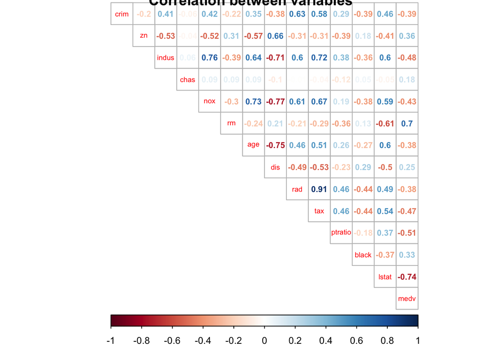

```r
corrplot(correlation_Boston, method = "number", type = "upper", cl.pos = "b", tl.pos = "d", tl.cex = 0.6, cl.cex = 0.8, number.cex = 0.7 , title = "Correlation between variables")
```

### Scaling the dataset and converting the scaled dataset to data frame

```r
scaled_Boston <- scale(Boston)
class(scaled_Boston)
```

```
## [1] "matrix"
```

```r
scaled_Boston <- as.data.frame(scaled_Boston)
```

### Creating categorical variable crime from the numerical variable crim

```r
bins <- quantile(scaled_Boston$crim)
bins
```

```
##           0%          25%          50%          75%         100%
## -0.419366929 -0.410563278 -0.390280295  0.007389247  9.924109610
```

```r
crime <- cut(scaled_Boston$crim, breaks = bins, include.lowest = TRUE, label = c("low", "med_low", "med_high", "high"))
table(crime)
```

```
## crime
##      low  med_low med_high     high
##      127      126      126      127
```

```r
scaled_Boston <- dplyr::select(scaled_Boston, -crim)
scaled_Boston <- data.frame(scaled_Boston, crime)
```

### Dividing the dataset for training and testing

```r
n <- nrow(scaled_Boston)

ind <- sample(n,  size = n * 0.8)

train <- scaled_Boston[ind, ]

test <- scaled_Boston[-ind, ]

correct_classes <- dplyr::select(test, crime)

test <- dplyr::select(test, -crime)
```

### Linear discriminant analysis (LDA)

Target variable is crime and all the other variables are explanatory variables.

```r
lda.crime <- lda(crime ~ ., data = train)
lda.crime
```

```
## Call:
## lda(crime ~ ., data = train)
##
## Prior probabilities of groups:
##       low   med_low  med_high      high
## 0.2326733 0.2351485 0.2574257 0.2747525
##
## Group means:
##                  zn      indus        chas        nox          rm
## low       0.9313544 -0.8838439 -0.14667693 -0.8656905  0.39554800
## med_low  -0.1254926 -0.3575909 -0.02367011 -0.6001002 -0.15256144
## med_high -0.3874684  0.2527133  0.18195173  0.4549487  0.03610161
## high     -0.4872402  1.0169382 -0.05951284  1.0563989 -0.34459859
##                 age        dis        rad        tax    ptratio
## low      -0.9254525  0.8230709 -0.6947544 -0.7269244 -0.4010722
## med_low  -0.3438171  0.3201303 -0.5587518 -0.5024993 -0.1238669
## med_high  0.4553437 -0.4129688 -0.4010119 -0.2720049 -0.2819199
## high      0.8288259 -0.8581190  1.6399445  1.5153545  0.7828912
##                black       lstat        medv
## low       0.38026900 -0.77129296  0.48525474
## med_low   0.31652406 -0.15057618  0.03614799
## med_high  0.03374428  0.06367754  0.10369918
## high     -0.80256111  0.90477878 -0.74293019
##
## Coefficients of linear discriminants:
##                 LD1         LD2         LD3
## zn       0.12182335  0.58766350 -1.03335598
## indus    0.02918202 -0.34004331  0.05498980
## chas    -0.08974919 -0.04296633  0.10866345
## nox      0.36476421 -0.74268267 -1.34436159
## rm      -0.08119468 -0.05182298 -0.22487798
## age      0.32245959 -0.43229556  0.01861156
## dis     -0.06720380 -0.27991687  0.14848192
## rad      3.04318332  1.02935296 -0.03447588
## tax     -0.05025497 -0.02146466  0.61735276
## ptratio  0.12909479 -0.05652081 -0.38457218
## black   -0.13197226  0.04957228  0.08923490
## lstat    0.21581025 -0.19372033  0.35942506
## medv     0.14790004 -0.44160004 -0.10868621
##
## Proportion of trace:
##    LD1    LD2    LD3
## 0.9444 0.0424 0.0132
```

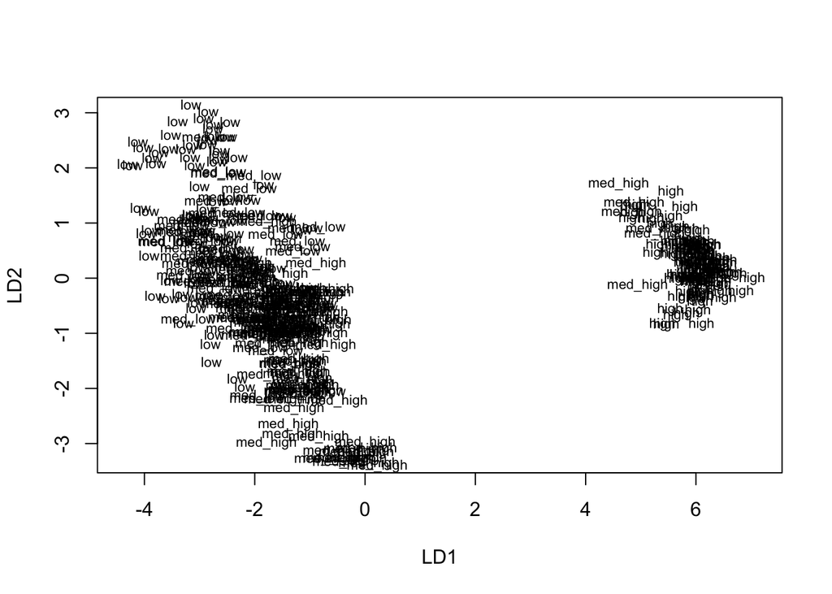

```r
plot(lda.crime, dimen = 2)
```

### Testing how well the model predicts values

```r
lda.pred <- predict(lda.crime, newdata = test)
lda.pred
```

```
## $class
##   [1] med_low  med_low  med_low  med_low  med_low  med_low  med_high
##   [8] med_high med_low  med_low  low      med_low  med_low  low
##  [15] low      low      med_low  med_low  med_low  med_low  low
##  [22] med_low  low      med_high med_low  med_high med_high med_high
##  [29] med_high med_high med_high med_high med_high med_high low
##  [36] low      low      low      low      low      low      med_low
##  [43] med_high med_low  med_low  med_high med_low  med_low  med_high
##  [50] low      low      med_low  low      low      low      low
##  [57] low      med_high med_high low      med_low  low      low
##  [64] low      low      low      low      low      med_low  med_low
##  [71] med_low  med_low  med_low  med_low  med_low  med_low  med_low
##  [78] med_low  low      high     high     high     high     high
##  [85] high     high     high     high     high     high     high
##  [92] high     high     high     high     med_high med_high med_high
```

[output cut: 212 more lines]

```r
cross_tab <- table(correct = correct_classes$crime, predicted = lda.pred$class)
cross_tab
```

```
##           predicted
## correct    low med_low med_high high
##   low       20      10        3    0
##   med_low    9      13        9    0
##   med_high   1      10       11    0
##   high       0       0        0   16
```

```r
prop.table(cross_tab, 1)
```

```
##           predicted
## correct           low    med_low   med_high       high
##   low      0.60606061 0.30303030 0.09090909 0.00000000
##   med_low  0.29032258 0.41935484 0.29032258 0.00000000
##   med_high 0.04545455 0.45454545 0.50000000 0.00000000
##   high     0.00000000 0.00000000 0.00000000 1.00000000
```

From the cross tabulation’s percentage table we can see that the model predicts low and high classes well but there are more error with the classes that are “in the middle” (med_low, med_high).

### Clustering

First scaling the dataset

```r
library(MASS)
data("Boston")
str(Boston)
```

```
## 'data.frame':    506 obs. of  14 variables:
##  $ crim   : num  0.00632 0.02731 0.02729 0.03237 0.06905 ...
##  $ zn     : num  18 0 0 0 0 0 12.5 12.5 12.5 12.5 ...
##  $ indus  : num  2.31 7.07 7.07 2.18 2.18 2.18 7.87 7.87 7.87 7.87 ...
##  $ chas   : int  0 0 0 0 0 0 0 0 0 0 ...
##  $ nox    : num  0.538 0.469 0.469 0.458 0.458 0.458 0.524 0.524 0.524 0.524 ...
##  $ rm     : num  6.58 6.42 7.18 7 7.15 ...
##  $ age    : num  65.2 78.9 61.1 45.8 54.2 58.7 66.6 96.1 100 85.9 ...
##  $ dis    : num  4.09 4.97 4.97 6.06 6.06 ...
##  $ rad    : int  1 2 2 3 3 3 5 5 5 5 ...
##  $ tax    : num  296 242 242 222 222 222 311 311 311 311 ...
##  $ ptratio: num  15.3 17.8 17.8 18.7 18.7 18.7 15.2 15.2 15.2 15.2 ...
##  $ black  : num  397 397 393 395 397 ...
##  $ lstat  : num  4.98 9.14 4.03 2.94 5.33 ...
##  $ medv   : num  24 21.6 34.7 33.4 36.2 28.7 22.9 27.1 16.5 18.9 ...
```

```r
Boston <- scale(Boston)
str(Boston)
```

```
##  num [1:506, 1:14] -0.419 -0.417 -0.417 -0.416 -0.412 ...
##  - attr(*, "dimnames")=List of 2
##   ..$ : chr [1:506] "1" "2" "3" "4" ...
##   ..$ : chr [1:14] "crim" "zn" "indus" "chas" ...
##  - attr(*, "scaled:center")= Named num [1:14] 3.6135 11.3636 11.1368 0.0692 0.5547 ...
##   ..- attr(*, "names")= chr [1:14] "crim" "zn" "indus" "chas" ...
##  - attr(*, "scaled:scale")= Named num [1:14] 8.602 23.322 6.86 0.254 0.116 ...
##   ..- attr(*, "names")= chr [1:14] "crim" "zn" "indus" "chas" ...
```

```r
Boston <- as.data.frame(Boston)
str(Boston)
```

```
## 'data.frame':    506 obs. of  14 variables:
##  $ crim   : num  -0.419 -0.417 -0.417 -0.416 -0.412 ...
##  $ zn     : num  0.285 -0.487 -0.487 -0.487 -0.487 ...
##  $ indus  : num  -1.287 -0.593 -0.593 -1.306 -1.306 ...
##  $ chas   : num  -0.272 -0.272 -0.272 -0.272 -0.272 ...
##  $ nox    : num  -0.144 -0.74 -0.74 -0.834 -0.834 ...
##  $ rm     : num  0.413 0.194 1.281 1.015 1.227 ...
##  $ age    : num  -0.12 0.367 -0.266 -0.809 -0.511 ...
##  $ dis    : num  0.14 0.557 0.557 1.077 1.077 ...
##  $ rad    : num  -0.982 -0.867 -0.867 -0.752 -0.752 ...
##  $ tax    : num  -0.666 -0.986 -0.986 -1.105 -1.105 ...
##  $ ptratio: num  -1.458 -0.303 -0.303 0.113 0.113 ...
##  $ black  : num  0.441 0.441 0.396 0.416 0.441 ...
##  $ lstat  : num  -1.074 -0.492 -1.208 -1.36 -1.025 ...
##  $ medv   : num  0.16 -0.101 1.323 1.182 1.486 ...
```

Calculating the distances between the observations

```r
dist_eu <- dist(Boston)
summary(dist_eu)
```

```
##    Min. 1st Qu.  Median    Mean 3rd Qu.    Max.
##  0.1343  3.4625  4.8241  4.9111  6.1863 14.3970
```

[output not shown]